# Forecast of Next Month’s Number of Mortgaged House Sale in Turkey by Using Linear Regression Model and Other Techniques

Muhammed Ikbal Baykal - IE360 - Fall 2020

# Introduction

> Mortgaged House Sale Statistics

Home loans are commonly referred to as mortgages, but a mortgage is actually a charge over a property. When a bank lends money, it requires security against a borrower’s failure to repay the money. The borrower grants the bank a mortgage over his or her property. If the borrower repays the debt secured by the mortgage, the mortgage is discharged. If not, the bank can sell the property to recover the money it is owed. This is called a mortgagee sale.

The aim of the study is to provide a forecast for December 2020 by building a time series regression model for forecasting next month’s value of the target variable. Data was taken from EVDS website. In this study, mortgaged house sales in Turkey between 2015-2020 will be examined and economic factors suitable for this data will be discussed. Suitable regression models for the data will be produced by using correlations between the data and other factors. After the model is produced, the development of the model will be provided by adding or removing other factors and it will be stopped when the most suitable model for the data is found. The forecast will be made for December 2020 according to the most suitable model.

Time series concepts will be used throughout the study and the data will be interpreted accordingly.

Mentioned economic factors that will be used in the study are:

> Total House Sale Statistics

> Interest Rate For House Credits

> Interest Rate

> House (Residential Property) Price Index

> Housing Unit Prices

> Consumer Confidence Index (CCI)

# Analysis of Data

## Data Manipulation

Libraries that are likely to be used throughout the study have been added.

```r
library(ggplot2)
library(zoo)
library(data.table)
library(fpp)
library(fpp2)
library(GGally)
library(readxl)
library(corrplot)
library(xts)
library(astsa)
library(gridExtra)
library(lubridate)
library(dplyr)
```

Data was imported from Excel and read in data.table format. Some manipulations and arrangements were made to make the data understandable. Column names changed and date format set. Here you can see the first 5 rows of the all data.

```r
setwd("C:/Users/90533/Desktop")
mydata <- as.data.table(read_excel("EVDS (3).xlsx"))
colnames(mydata) = c("Date", "Mortgaged House Sale Statistics", "Total House Sale Statistics", "Interest Rate For House Credits", "Interest Rate", "House Price Index", "Unit House Prices", "Consumer Confidence Index")
mydata$Date <- as.yearmon(mydata$Date)
head(mydata, 5)
```

```
##        Date Mortgaged House Sale Statistics Total House Sale Statistics
## 1: Oca 2015                           33178                       86167
## 2: Şub 2015                           36952                       95021
## 3: Mar 2015                           45315                      116030
## 4: Nis 2015                           46063                      119317
## 5: May 2015                           40086                      107888
##    Interest Rate For House Credits Interest Rate House Price Index
## 1:                         11.0060        9.1520              74.2
## 2:                         10.7975        9.0250              75.4
## 3:                         10.8175        9.2625              76.6
## 4:                         10.9650        9.4850              77.7
## 5:                         11.4900        9.6240              78.9
##    Unit House Prices Consumer Confidence Index
## 1:            1806.4                  89.34782
## 2:            1844.7                  88.79513
## 3:            1882.9                  86.48974
## 4:            1916.8                  87.42186
## 5:            1952.9                  86.79943
```

## Data Visualization

First of all, We can draw the histogram of our target variable to find some information about the data. Analyzing the target data is useful every time.

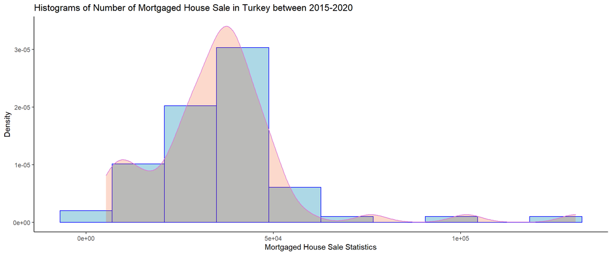

```r
ggplot(mydata, aes(x=`Mortgaged House Sale Statistics`, y=..density..)) +
  geom_histogram(colour="blue", fill="lightblue", bins = 10)+
  geom_density(alpha=.2, colour="orchid", fill="orangered2") + labs(title = "Histograms of Number of Mortgaged House Sale in Turkey between 2015-2020",    "Number of Mortgaged House Sale", y = "Density") + theme_classic()
```

From the histogram, we can conclude that we have two outlier values, which correspond to a number higher than 1e+05, in the target data. We can filter the values higher than 1e+05 by using the “filter” function:

```r
mydata%>%filter(mydata$`Mortgaged House Sale Statistics`>1e+05)
```

```
##        Date Mortgaged House Sale Statistics Total House Sale Statistics
## 1: Haz 2020                          101504                      190012
## 2: Tem 2020                          130721                      229357
##    Interest Rate For House Credits Interest Rate House Price Index
## 1:                          9.3025        7.3825             139.5
## 2:                          9.1140        7.3440             141.4
##    Unit House Prices Consumer Confidence Index
## 1:            3403.9                  82.97922
## 2:            3452.7                  82.82247
```

```r
mydata2 <- mydata[-66,]
mydataout <- mydata2[-66,]
```

When we look at the information above, it is possible to say that outliers are not seasonal, they have an instant rise as a result of the fall in housing interest rates in the summer of 2020. This is a result of a policy of Government of Turkish Republic after COVID-19 pandemic.

The point and line plots of our target variable can also be drawn in two different ways:

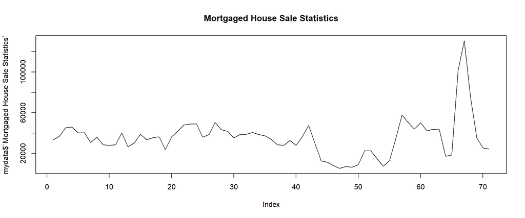

```r
plot(mydata$`Mortgaged House Sale Statistics`, main = "Mortgaged House Sale Statistics", type="l")
```

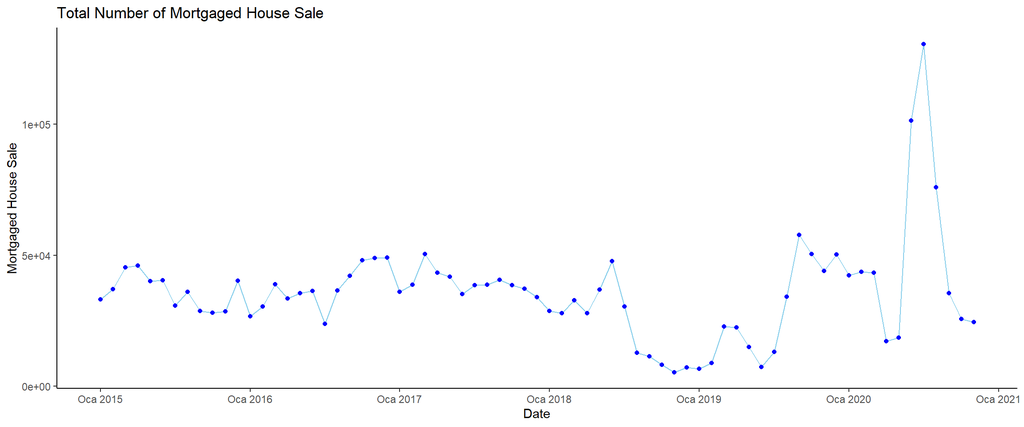

```r
ggplot(mydata, aes(x = Date, y=`Mortgaged House Sale Statistics`)) + geom_line(color="skyblue") + labs(title = "Total Number of Mortgaged House Sale", x = "Date", y= "Mortgaged House Sale") + geom_point(color="blue") + theme_classic()
```

In order to get rid of the variance effect and to see it more clearly, another drawing can be made on the logarithm of the target variable.

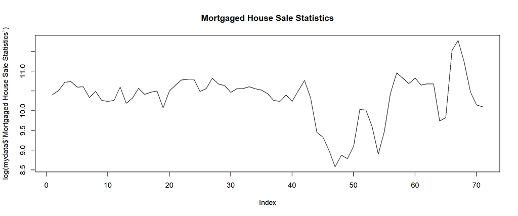

```r
plot(log(mydata$`Mortgaged House Sale Statistics`), main = "Mortgaged House Sale Statistics", type="l")
```

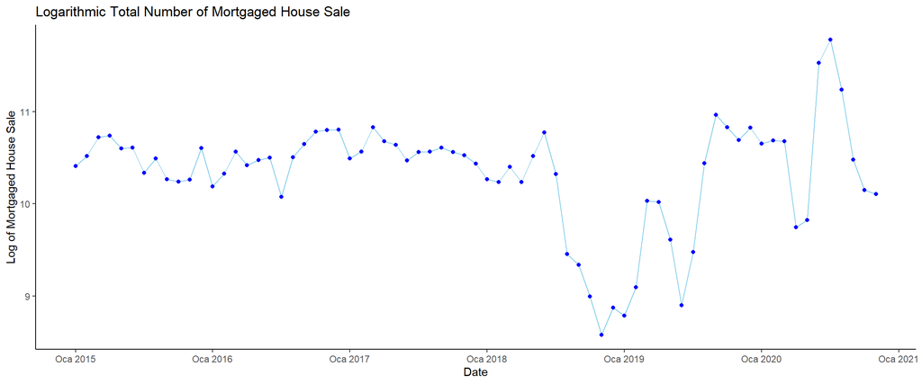

```r
ggplot(mydata, aes(x = Date, y=log(mydata$`Mortgaged House Sale Statistics`))) + geom_line(color="skyblue") + labs(title = "Logarithmic Total Number of Mortgaged House Sale", x = "Date", y= "Log of Mortgaged House Sale") + geom_point(color="blue") + theme_classic()
```

When the plot is examined, it does not seem possible to encounter a sharp seasonal or upward or downward trend in the data. In general, it can be said that the data was stable, there was a serious decrease in 2018 and a serious increase in 2020. The reason for the decrease in 2018 can be seen as the Priest Brunson incident and the policy of increasing the interest rates applied as a result of the increase in the exchange rate. In 2020, things have come to a standstill in many sectors within the framework of pandemic conditions. As a solution, the Government of the Republic of Turkey, lowered interest rates for house sales and aimed at the revival of all sectors.

For extra information, the aurocorrelation factor can be examined.

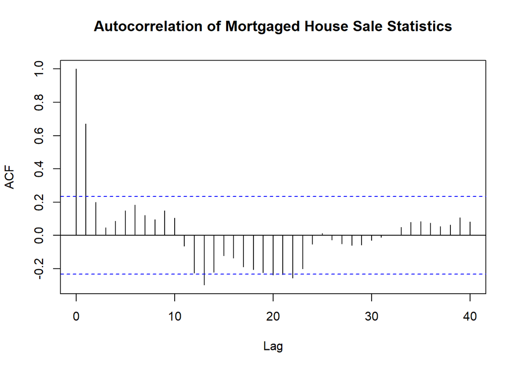

```r
acf(mydata$`Mortgaged House Sale Statistics`, lag.max = 40, main = "Autocorrelation of Mortgaged House Sale Statistics")
```

## Building Models For Forecast

Before building a model, examination of correlations among target variable and other factors will be useful. This examination will be made in two different ways. First, the correlation among target variable and other factors will be found and plotted. After that, logarithmic results will be found and plotted.

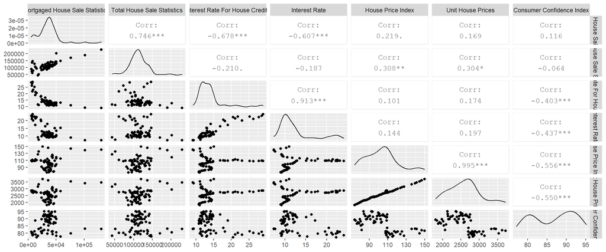

```r
ggpairs(mydata[,-1])
```

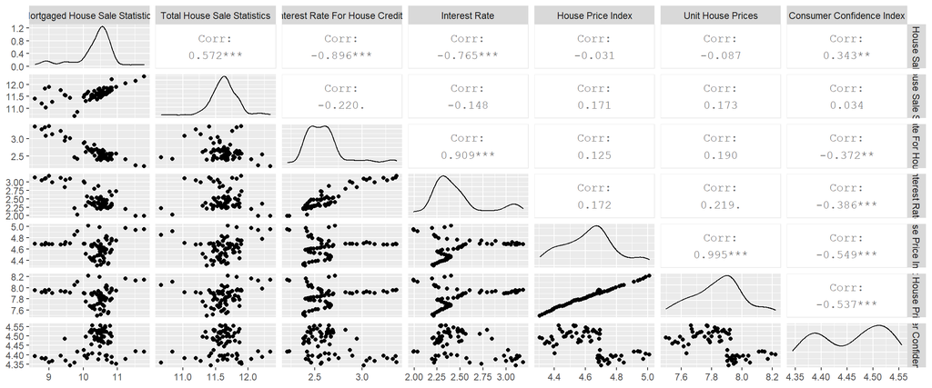

```r
ggpairs(log(mydata[,-1]))
```

As can be seen from the correlogram, mortgaged house sale statistics are mostly related to total house statistics, interest rate for house credits and interest rate. In the suitable model to be created, these data will be needed in order for the model to have meaning.

Now, the first model can be created. It is very appropriate to start with only month factor. To do that, a new column is created to give the corresponding number for each month in the row. After the manipulation of the data, first model is created. Here you can find the model:

```r
month <- seq(1,12, by=1)
mydata <- cbind(mydata,month)
l <- lm(`Mortgaged House Sale Statistics`~ as.factor(month), data=mydata)
summary(l)
```

```
##
## Call:
## lm(formula = `Mortgaged House Sale Statistics` ~ as.factor(month),
##     data = mydata)
##
## Residuals:
##    Min     1Q Median     3Q    Max
## -37440  -8821   -427   7349  86175
##
## Coefficients:
##                    Estimate Std. Error t value Pr(>|t|)
## (Intercept)           28868       8308   3.475 0.000965 ***
## as.factor(month)2      2236      11749   0.190 0.849723
## as.factor(month)3     10038      11749   0.854 0.396318
## as.factor(month)4      2847      11749   0.242 0.809390
## as.factor(month)5      2384      11749   0.203 0.839898
## as.factor(month)6     15891      11749   1.353 0.181342
## as.factor(month)7     15678      11749   1.334 0.187183
## as.factor(month)8     10154      11749   0.864 0.390932
## as.factor(month)9      7135      11749   0.607 0.545970
## as.factor(month)10     4256      11749   0.362 0.718477
## as.factor(month)11     2537      11749   0.216 0.829780
## as.factor(month)12     7295      12322   0.592 0.556097
## ---
## Signif. codes:  0 '***' 0.001 '**' 0.01 '*' 0.05 '.' 0.1 ' ' 1
##
## Residual standard error: 20350 on 59 degrees of freedom
## Multiple R-squared:  0.0708, Adjusted R-squared:  -0.1024
## F-statistic: 0.4087 on 11 and 59 DF,  p-value: 0.9467
```

By looking at the adjusted R value, it can be seen that the model is not appropriate. All factored months are not significant for the data. If we check the residuals:

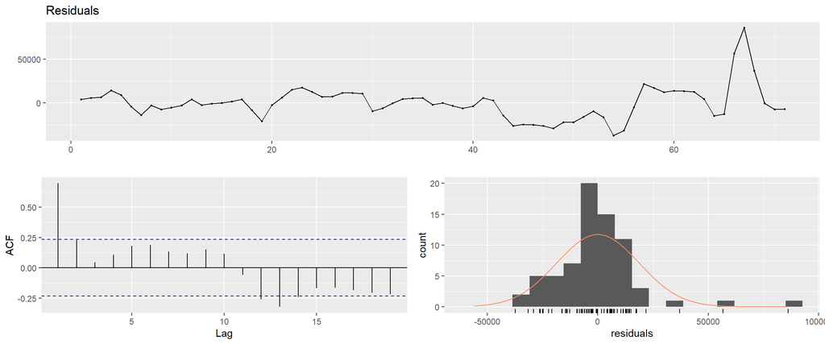

```
##
##  Breusch-Godfrey test for serial correlation of order up to 15
##
## data:  Residuals
## LM test = 59.38, df = 15, p-value = 3.223e-07
```

```r
checkresiduals(l)
```

```r
mydata <- mydata[, trend:=1:.N]
l2 <- lm(`Mortgaged House Sale Statistics`~ as.factor(month) + trend, data=mydata)
summary(l2)
```

```
##
## Call:
## lm(formula = `Mortgaged House Sale Statistics` ~ as.factor(month) +
##     trend, data = mydata)
##
## Residuals:
##    Min     1Q Median     3Q    Max
## -38385  -9183   -505   7935  84600
##
## Coefficients:
##                    Estimate Std. Error t value Pr(>|t|)
## (Intercept)        27240.49    9154.83   2.976  0.00426 **
## as.factor(month)2   2183.34   11830.60   0.185  0.85423
## as.factor(month)3   9933.51   11832.43   0.840  0.40463
## as.factor(month)4   2689.18   11835.47   0.227  0.82106
## as.factor(month)5   2174.02   11839.73   0.184  0.85495
## as.factor(month)6  15628.86   11845.20   1.319  0.19221
## as.factor(month)7  15363.03   11851.88   1.296  0.20002
## as.factor(month)8   9786.70   11859.77   0.825  0.41264
## as.factor(month)9   6715.21   11868.88   0.566  0.57372
## as.factor(month)10  3783.21   11879.18   0.318  0.75127
## as.factor(month)11  2012.05   11890.69   0.169  0.86622
## as.factor(month)12  7032.49   12421.90   0.566  0.57348
## trend                 52.49     119.99   0.437  0.66338
## ---
## Signif. codes:  0 '***' 0.001 '**' 0.01 '*' 0.05 '.' 0.1 ' ' 1
##
## Residual standard error: 20490 on 58 degrees of freedom
## Multiple R-squared:  0.07385,    Adjusted R-squared:  -0.1178
## F-statistic: 0.3854 on 12 and 58 DF,  p-value: 0.9636
```

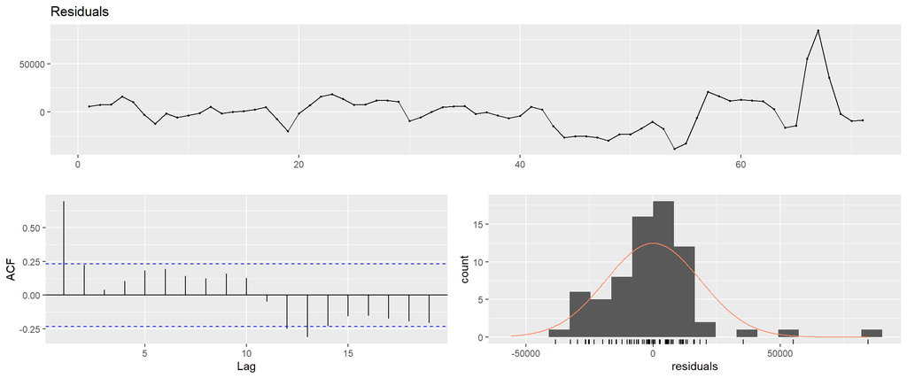

```
##
##  Breusch-Godfrey test for serial correlation of order up to 16
##
## data:  Residuals
## LM test = 59.456, df = 16, p-value = 6.463e-07
```

```r
checkresiduals(l2)
```

```r
l3 <- lm(formula = `Mortgaged House Sale Statistics` ~ `Interest Rate For House Credits`, data = mydata)
summary(l3)
```

```
##
## Call:
## lm(formula = `Mortgaged House Sale Statistics` ~ `Interest Rate For House Credits`,
##     data = mydata)
##
## Residuals:
##    Min     1Q Median     3Q    Max
## -26710  -6789  -2114   3147  79307
##
## Coefficients:
##                                   Estimate Std. Error t value Pr(>|t|)
## (Intercept)                          78158       5815  13.440  < 2e-16 ***
## `Interest Rate For House Credits`    -2934        383  -7.661 8.34e-11 ***
## ---
## Signif. codes:  0 '***' 0.001 '**' 0.01 '*' 0.05 '.' 0.1 ' ' 1
##
## Residual standard error: 14350 on 69 degrees of freedom
## Multiple R-squared:  0.4596, Adjusted R-squared:  0.4518
## F-statistic: 58.68 on 1 and 69 DF,  p-value: 8.344e-11
```

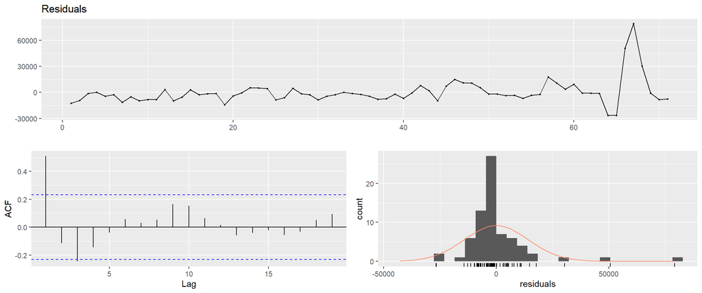

```
##
##  Breusch-Godfrey test for serial correlation of order up to 10
##
## data:  Residuals
## LM test = 42.184, df = 10, p-value = 6.955e-06
```

```r
checkresiduals(l3)
```

A better result is obtained in this way. Interest Rate For House Credits is a significant factor in the model. Our R-squared value is 0.4518 which is an appropriate value for the first model. As a second improvement, Total House Sale Statistics can be added to the model.

```r
l4 <- lm(formula = `Mortgaged House Sale Statistics` ~ `Interest Rate For House Credits` + `Total House Sale Statistics`, data = mydata)
summary(l4)
```

```
##
## Call:
## lm(formula = `Mortgaged House Sale Statistics` ~ `Interest Rate For House Credits` +
##     `Total House Sale Statistics`, data = mydata)
##
## Residuals:
##    Min     1Q Median     3Q    Max
## -25704  -3474     85   1469  35016
##
## Coefficients:
##                                     Estimate Std. Error t value Pr(>|t|)
## (Intercept)                       22237.6198  5421.1021   4.102 0.000112 ***
## `Interest Rate For House Credits` -2359.4751   214.4350 -11.003  < 2e-16 ***
## `Total House Sale Statistics`         0.4141     0.0325  12.742  < 2e-16 ***
## ---
## Signif. codes:  0 '***' 0.001 '**' 0.01 '*' 0.05 '.' 0.1 ' ' 1
##
## Residual standard error: 7854 on 68 degrees of freedom
## Multiple R-squared:  0.8405, Adjusted R-squared:  0.8358
## F-statistic: 179.1 on 2 and 68 DF,  p-value: < 2.2e-16
```

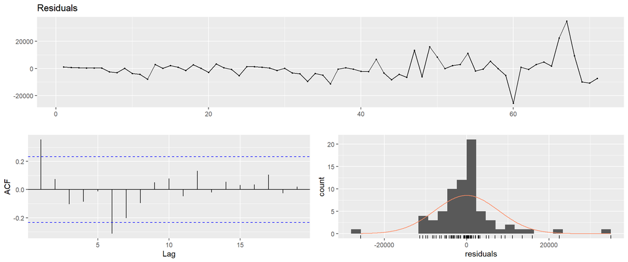

```
##
##  Breusch-Godfrey test for serial correlation of order up to 10
##
## data:  Residuals
## LM test = 28.162, df = 10, p-value = 0.001701
```

```r
checkresiduals(l4)
```

New adjusted R squared value is 0.8358 which means there is a huge improvement on the model. This model will give us better estimates while predicting the next months’ values. Now, we can look for a model with logarithmic values of the variables.

```r
l5 <- lm(formula = log(mydata$`Mortgaged House Sale Statistics`) ~ log(mydata$`Interest Rate For House Credits`) + log(mydata$`Total House Sale Statistics`), data = mydata)
summary(l5)
```

```
##
## Call:
## lm(formula = log(mydata$`Mortgaged House Sale Statistics`) ~
##     log(mydata$`Interest Rate For House Credits`) + log(mydata$`Total House Sale Statistics`),
##     data = mydata)
##
## Residuals:
##      Min       1Q   Median       3Q      Max
## -0.34874 -0.08256 -0.01285  0.08709  0.26598
##
## Coefficients:
##                                               Estimate Std. Error t value
## (Intercept)                                    4.77896    0.78914   6.056
## log(mydata$`Interest Rate For House Credits`) -1.87973    0.06400 -29.373
## log(mydata$`Total House Sale Statistics`)      0.90441    0.06322  14.307
##                                               Pr(>|t|)
## (Intercept)                                   6.79e-08 ***
## log(mydata$`Interest Rate For House Credits`)  < 2e-16 ***
## log(mydata$`Total House Sale Statistics`)      < 2e-16 ***
## ---
## Signif. codes:  0 '***' 0.001 '**' 0.01 '*' 0.05 '.' 0.1 ' ' 1
##
## Residual standard error: 0.1352 on 68 degrees of freedom
## Multiple R-squared:  0.9508, Adjusted R-squared:  0.9494
## F-statistic: 657.7 on 2 and 68 DF,  p-value: < 2.2e-16
```

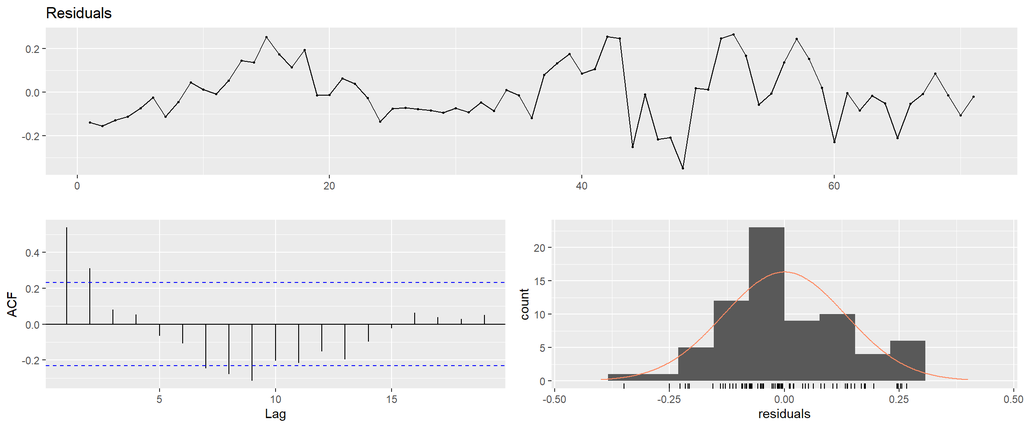

```
##
##  Breusch-Godfrey test for serial correlation of order up to 10
##
## data:  Residuals
## LM test = 25.785, df = 10, p-value = 0.004041
```

```r
checkresiduals(l5)
```

A better R squared value is obtained and the mean of the residuals is almost equal to zero. A better model can be created by adding Interest Rate and Consumer Confidence Index which are also related to Mortgaged House Sale Statistics.

```r
l6 <- lm(formula = log(mydata$`Mortgaged House Sale Statistics`) ~ log(mydata$`Interest Rate For House Credits`) + log(mydata$`Total House Sale Statistics`) + log(mydata$`Interest Rate`) + log(mydata$`Consumer Confidence Index`), data = mydata)
summary(l6)
```

```
##
## Call:
## lm(formula = log(mydata$`Mortgaged House Sale Statistics`) ~
##     log(mydata$`Interest Rate For House Credits`) + log(mydata$`Total House Sale Statistics`) +
##         log(mydata$`Interest Rate`) + log(mydata$`Consumer Confidence Index`),
##     data = mydata)
##
## Residuals:
##       Min        1Q    Median        3Q       Max
## -0.292585 -0.108049  0.006884  0.069328  0.280778
##
## Coefficients:
##                                               Estimate Std. Error t value
## (Intercept)                                    3.26942    1.45075   2.254
## log(mydata$`Interest Rate For House Credits`) -2.21922    0.14529 -15.275
## log(mydata$`Total House Sale Statistics`)      0.88716    0.06053  14.656
## log(mydata$`Interest Rate`)                    0.34755    0.12229   2.842
## log(mydata$`Consumer Confidence Index`)        0.39023    0.25775   1.514
##                                               Pr(>|t|)
## (Intercept)                                    0.02755 *
## log(mydata$`Interest Rate For House Credits`)  < 2e-16 ***
## log(mydata$`Total House Sale Statistics`)      < 2e-16 ***
## log(mydata$`Interest Rate`)                    0.00596 **
## log(mydata$`Consumer Confidence Index`)        0.13480
## ---
## Signif. codes:  0 '***' 0.001 '**' 0.01 '*' 0.05 '.' 0.1 ' ' 1
##
## Residual standard error: 0.1283 on 66 degrees of freedom
## Multiple R-squared:  0.957,  Adjusted R-squared:  0.9544
## F-statistic: 367.4 on 4 and 66 DF,  p-value: < 2.2e-16
```

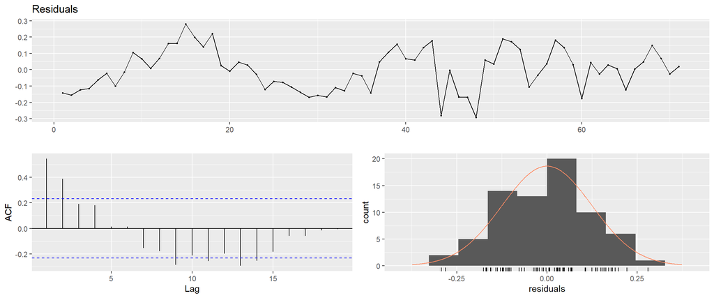

```
##
##  Breusch-Godfrey test for serial correlation of order up to 10
##
## data:  Residuals
## LM test = 27.473, df = 10, p-value = 0.002191
```

```r
checkresiduals(l6)
```

Model is almost done except the autocorrelation problem. Lagged residual values should be updated.

```r
mydata <- mydata[,residual_1:=0]
mydata$residual_1[1]<- NA
mydata$residual_1[2:71]<- residuals(l6)[1:70]
model <- lm(formula = log(mydata$`Mortgaged House Sale Statistics`) ~ log(mydata$`Interest Rate For House Credits`) + log(mydata$`Total House Sale Statistics`) + log(mydata$`Interest Rate`) + log(mydata$`Consumer Confidence Index` + residual_1), data = mydata)
summary(model)
```

```
##
## Call:
## lm(formula = log(mydata$`Mortgaged House Sale Statistics`) ~
##     log(mydata$`Interest Rate For House Credits`) + log(mydata$`Total House Sale Statistics`) +
##         log(mydata$`Interest Rate`) + log(mydata$`Consumer Confidence Index` +
##         residual_1), data = mydata)
##
## Residuals:
##       Min        1Q    Median        3Q       Max
## -0.284297 -0.108948  0.005947  0.069895  0.277683
##
## Coefficients:
##                                                      Estimate Std. Error
## (Intercept)                                           3.26472    1.44754
## log(mydata$`Interest Rate For House Credits`)        -2.22822    0.14485
## log(mydata$`Total House Sale Statistics`)             0.87750    0.06089
## log(mydata$`Interest Rate`)                           0.34953    0.12174
## log(mydata$`Consumer Confidence Index` + residual_1)  0.42113    0.25630
##                                                      t value Pr(>|t|)
## (Intercept)                                            2.255  0.02748 *
## log(mydata$`Interest Rate For House Credits`)        -15.383  < 2e-16 ***
## log(mydata$`Total House Sale Statistics`)             14.411  < 2e-16 ***
## log(mydata$`Interest Rate`)                            2.871  0.00551 **
## log(mydata$`Consumer Confidence Index` + residual_1)   1.643  0.10519
## ---
## Signif. codes:  0 '***' 0.001 '**' 0.01 '*' 0.05 '.' 0.1 ' ' 1
##
## Residual standard error: 0.1277 on 65 degrees of freedom
##   (1 observation deleted due to missingness)
## Multiple R-squared:  0.9581, Adjusted R-squared:  0.9555
## F-statistic: 371.2 on 4 and 65 DF,  p-value: < 2.2e-16
```

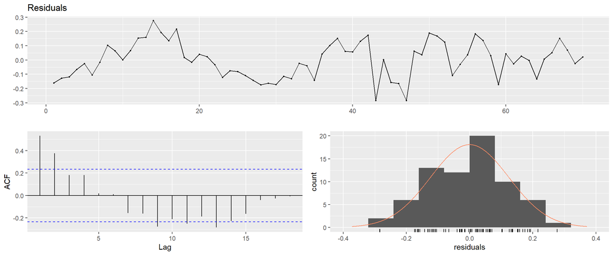

```
##
##  Breusch-Godfrey test for serial correlation of order up to 10
##
## data:  Residuals
## LM test = 26.129, df = 10, p-value = 0.003571
```

```r
checkresiduals(model)
```

The expected result could not be achieved in the model. The cause is unknown. No decrease in autoregression values was detected. Studies will continue to solve the problem.

Here you can see the plot of fitted values and residuals according to the model. Also, the plot of fitted values and logarithmic values of target variable is provided.

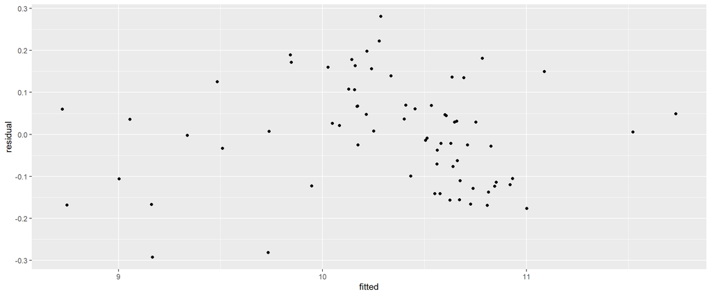

```r
mydata[,fitted := fitted(l6)]
mydata[,residual := residuals(l6)]

mydata %>%
  ggplot(aes(x=fitted, y=residual)) + geom_point()
```

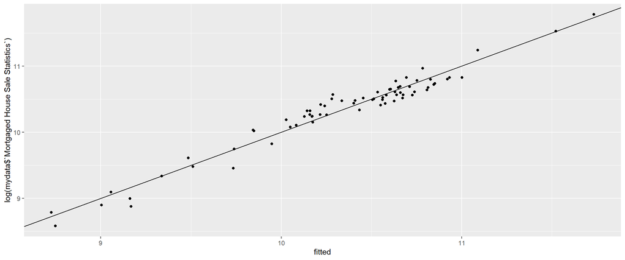

```r
mydata %>%
  ggplot(aes(x=fitted, y=log(mydata$`Mortgaged House Sale Statistics`))) +
  geom_point() +
  geom_abline(slope=1, intercept=0)
```

## Prediction (December 2020)

```r
x <- "2020-12"
x <- as.yearmon(x)
x
```

```
## [1] "Ara 2020"
```

```r
mydata=rbind(mydata, data.table(Date=x, month=as.factor(12)),fill=TRUE)
mydata[,fitted:=predict(l6, mydata[is.na(fitted)==TRUE])]
print(mydata[72]$fitted)
```

```
## [1] NA
```

```r
tail(mydata, 5)
```

```
##        Date Mortgaged House Sale Statistics Total House Sale Statistics
## 1: Ağu 2020                           76019                      170408
## 2: Eyl 2020                           35576                      136744
## 3: Eki 2020                           25566                      119574
## 4: Kas 2020                           24450                      112483
## 5: Ara 2020                              NA                          NA
##    Interest Rate For House Credits Interest Rate House Price Index
## 1:                          11.085        8.9750             144.4
## 2:                          14.150       10.2875             146.7
## 3:                          15.066       11.0400             149.9
## 4:                          15.675       13.0800                NA
## 5:                              NA            NA                NA
##    Unit House Prices Consumer Confidence Index month trend  residual_1   fitted
## 1:            3528.5                  79.77182     8    68  0.04874263 11.08909
## 2:            3619.7                  81.90816     9    69  0.14964398 10.40983
## 3:            3713.5                  81.54335    10    70  0.06959384 10.17439
## 4:                NA                  79.98411    11    71 -0.02537017 10.08361
## 5:                NA                        NA    12    NA          NA       NA
##       residual
## 1:  0.14964398
## 2:  0.06959384
## 3: -0.02537017
## 4:  0.02077557
## 5:          NA
```

# Conclusion

A model is obtained after analyzing and manipulating the data and other factors that affects the data. This model predicts monthly mortgaged house sales in Turkey by some errors.

Again, with a small error caused by the code, although there is no problem in the steps, the estimate cannot be placed in the decided cell. All aside, the fact that the data used does not have a trend and a sharp seasonality shows that the data is not suitable for creating such a model. It may be possible to achieve different and better results by trying different models.

## References

- [EVDS Web Page](https://evds2.tcmb.gov.tr/)
- [STHDA](http://www.sthda.com/english/)
- [Stackoverflow](https://stackoverflow.com/)

## Appendices

Click [here](https://bu-ie-360.github.io/fall20-mibaykal/files/HW333.Rmd) to reach the RMD file.